# report

daeyong.kim

2024-05-13

```r
library(ggplot2)
library(gridExtra)
library(MASS)
library(corrplot)
library(dplyr)
library(pheatmap)
library(rsample)
library(glmnet)
library(ISLR2)
```

# Colleage data set

```r
data(College)
```

## In this exercise, we will predict the number of applications received using the other variables in the College data set.

### EDA : Exploratory Data Analysis

```r
summary(College)
```

```
##  Private        Apps           Accept          Enroll       Top10perc
##  No :212   Min.   :   81   Min.   :   72   Min.   :  35   Min.   : 1.00
##  Yes:565   1st Qu.:  776   1st Qu.:  604   1st Qu.: 242   1st Qu.:15.00
##            Median : 1558   Median : 1110   Median : 434   Median :23.00
##            Mean   : 3002   Mean   : 2019   Mean   : 780   Mean   :27.56
##            3rd Qu.: 3624   3rd Qu.: 2424   3rd Qu.: 902   3rd Qu.:35.00
##            Max.   :48094   Max.   :26330   Max.   :6392   Max.   :96.00
##    Top25perc      F.Undergrad     P.Undergrad         Outstate
##  Min.   :  9.0   Min.   :  139   Min.   :    1.0   Min.   : 2340
##  1st Qu.: 41.0   1st Qu.:  992   1st Qu.:   95.0   1st Qu.: 7320
##  Median : 54.0   Median : 1707   Median :  353.0   Median : 9990
##  Mean   : 55.8   Mean   : 3700   Mean   :  855.3   Mean   :10441
##  3rd Qu.: 69.0   3rd Qu.: 4005   3rd Qu.:  967.0   3rd Qu.:12925
##  Max.   :100.0   Max.   :31643   Max.   :21836.0   Max.   :21700
##    Room.Board       Books           Personal         PhD
##  Min.   :1780   Min.   :  96.0   Min.   : 250   Min.   :  8.00
##  1st Qu.:3597   1st Qu.: 470.0   1st Qu.: 850   1st Qu.: 62.00
##  Median :4200   Median : 500.0   Median :1200   Median : 75.00
##  Mean   :4358   Mean   : 549.4   Mean   :1341   Mean   : 72.66
##  3rd Qu.:5050   3rd Qu.: 600.0   3rd Qu.:1700   3rd Qu.: 85.00
##  Max.   :8124   Max.   :2340.0   Max.   :6800   Max.   :103.00
##     Terminal       S.F.Ratio      perc.alumni        Expend
##  Min.   : 24.0   Min.   : 2.50   Min.   : 0.00   Min.   : 3186
##  1st Qu.: 71.0   1st Qu.:11.50   1st Qu.:13.00   1st Qu.: 6751
##  Median : 82.0   Median :13.60   Median :21.00   Median : 8377
##  Mean   : 79.7   Mean   :14.09   Mean   :22.74   Mean   : 9660
##  3rd Qu.: 92.0   3rd Qu.:16.50   3rd Qu.:31.00   3rd Qu.:10830
##  Max.   :100.0   Max.   :39.80   Max.   :64.00   Max.   :56233
##    Grad.Rate
##  Min.   : 10.00
##  1st Qu.: 53.00
##  Median : 65.00
##  Mean   : 65.46
##  3rd Qu.: 78.00
##  Max.   :118.00
```

samples : 777

Private Predictor)  
No : 212  
Yes : 565

Apps Predictor)  
Min : 81  
Median : 1558  
Mean : 3002  
Max : 48094

Private의 분포가 고르지않고, Yes쪽으로 편향된 것을 확인할 수 있다.

```r
str(College)
```

```
## 'data.frame':    777 obs. of  18 variables:
##  $ Private    : Factor w/ 2 levels "No","Yes": 2 2 2 2 2 2 2 2 2 2 ...
##  $ Apps       : num  1660 2186 1428 417 193 ...
##  $ Accept     : num  1232 1924 1097 349 146 ...
##  $ Enroll     : num  721 512 336 137 55 158 103 489 227 172 ...
##  $ Top10perc  : num  23 16 22 60 16 38 17 37 30 21 ...
##  $ Top25perc  : num  52 29 50 89 44 62 45 68 63 44 ...
##  $ F.Undergrad: num  2885 2683 1036 510 249 ...
##  $ P.Undergrad: num  537 1227 99 63 869 ...
##  $ Outstate   : num  7440 12280 11250 12960 7560 ...
##  $ Room.Board : num  3300 6450 3750 5450 4120 ...
##  $ Books      : num  450 750 400 450 800 500 500 450 300 660 ...
##  $ Personal   : num  2200 1500 1165 875 1500 ...
##  $ PhD        : num  70 29 53 92 76 67 90 89 79 40 ...
##  $ Terminal   : num  78 30 66 97 72 73 93 100 84 41 ...
##  $ S.F.Ratio  : num  18.1 12.2 12.9 7.7 11.9 9.4 11.5 13.7 11.3 11.5 ...
##  $ perc.alumni: num  12 16 30 37 2 11 26 37 23 15 ...
##  $ Expend     : num  7041 10527 8735 19016 10922 ...
##  $ Grad.Rate  : num  60 56 54 59 15 55 63 73 80 52 ...
```

observations : 777  
variables : 18  
categorical data : 1(Private) numerical data : 17

Private: 사립 대학 여부 (Yes/No)  
Apps: 접수된 지원서 수  
Accept: 합격한 학생 수  
Enroll: 등록한 학생 수  
Top10perc: 상위 10%의 고등학교 성적을 가진 학생 비율  
Top25perc: 상위 25%의 고등학교 성적을 가진 학생 비율  
F.Undergrad: 풀타임 학부생 수  
P.Undergrad: 파트타임 학부생 수  
outstate: 외지 학생 등록금 Room.Board: 숙소 및 식사비  
Books: 교재비  
Personal: 개인 경비  
PhD: 박사학위 보유한 교수 비율  
Terminal: 석사학위 보유한 교수 비율  
S.F Ratio : 학생/교수 비율  
perc.alumni: 기부한 동문 비율  
Expend: 학생 당 교육 비용 Grad.Rate: 졸업생 비율

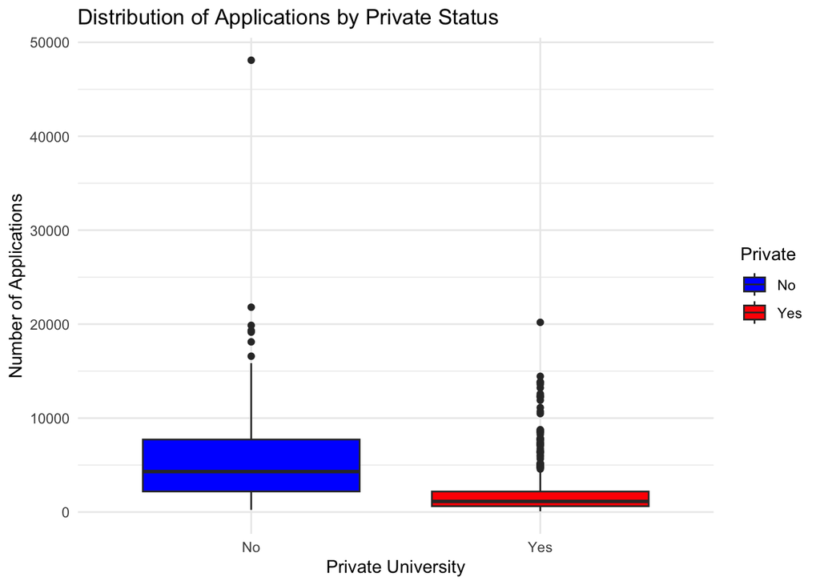

```r
ggplot(College, aes(x = Private, y = Apps, fill = Private)) +
  geom_boxplot() +
  labs(title = "Distribution of Applications by Private Status",
       x = "Private University",
       y = "Number of Applications") +
  scale_fill_manual(values = c("blue", "red")) +  # 색상 지정
  theme_minimal()
```

공립대학과 사립대학간의 차이를 비교한 boxplot이다. 위의 boxplot에서 볼 수 있듯이 공립과 사립 대학의 유무에 따라서 지원자의 수에 차이가 있다고 결론을 내릴 수 있다.

```r
private_no_data = subset(College, Private == "No")
private_yes_data = subset(College, Private == "Yes")
```

```r
t_test_result = t.test(private_no_data$Apps, private_yes_data$Apps)
print(t_test_result)
```

```
##
##  Welch Two Sample t-test
##
## data:  private_no_data$Apps and private_yes_data$Apps
## t = 9.7985, df = 244.49, p-value < 2.2e-16
## alternative hypothesis: true difference in means is not equal to 0
## 95 percent confidence interval:
##  2997.758 4506.223
## sample estimates:
## mean of x mean of y
##  5729.920  1977.929
```

p-value가 5% 이내이기 때문에, 두 집단 간 유의미한 차이가 있다고 할 수 있다.

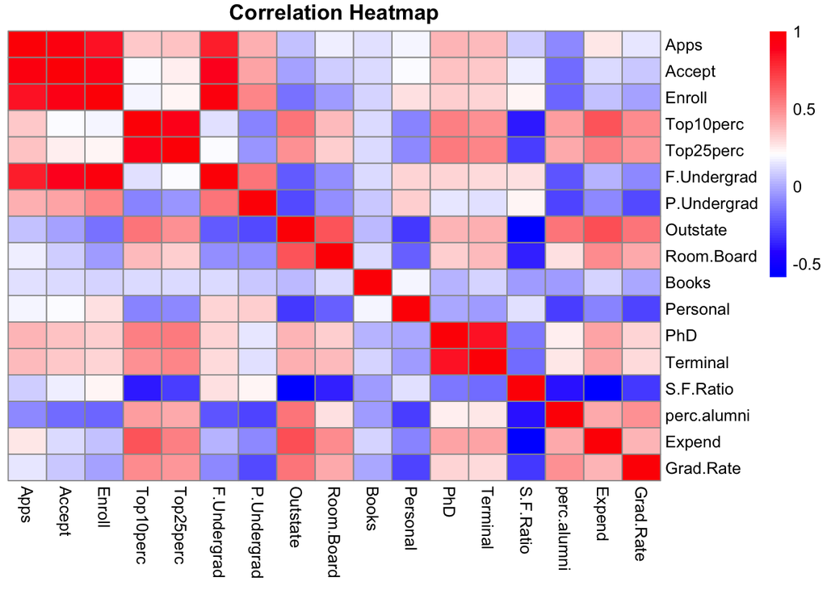

```r
sub_college = College %>% select(-Private)
correlation_matrix = cor(sub_college)
pheatmap(correlation_matrix,
         main = "Correlation Heatmap",
         color = colorRampPalette(c("blue", "white", "red"))(100),
         fontsize = 10,
         cluster_rows = FALSE, cluster_cols = FALSE)
```

Correlation Heatmap을 그려서 Apps와 다른 predictors 간의 상관관계를 시각적으로 표현하였다.  
F.Undergrad, Enroll, Accept이 Apps와 강한 상관관계를 보이는 것을 확인할 수 있다.

위의 boxplot과 Correlation Heatmap의 결과를 종합하자면, Apps를 예측하기 위한 predictors로 F.Undergrad, Enroll, Accept, Private이 적합하다고 결론을 내린다.

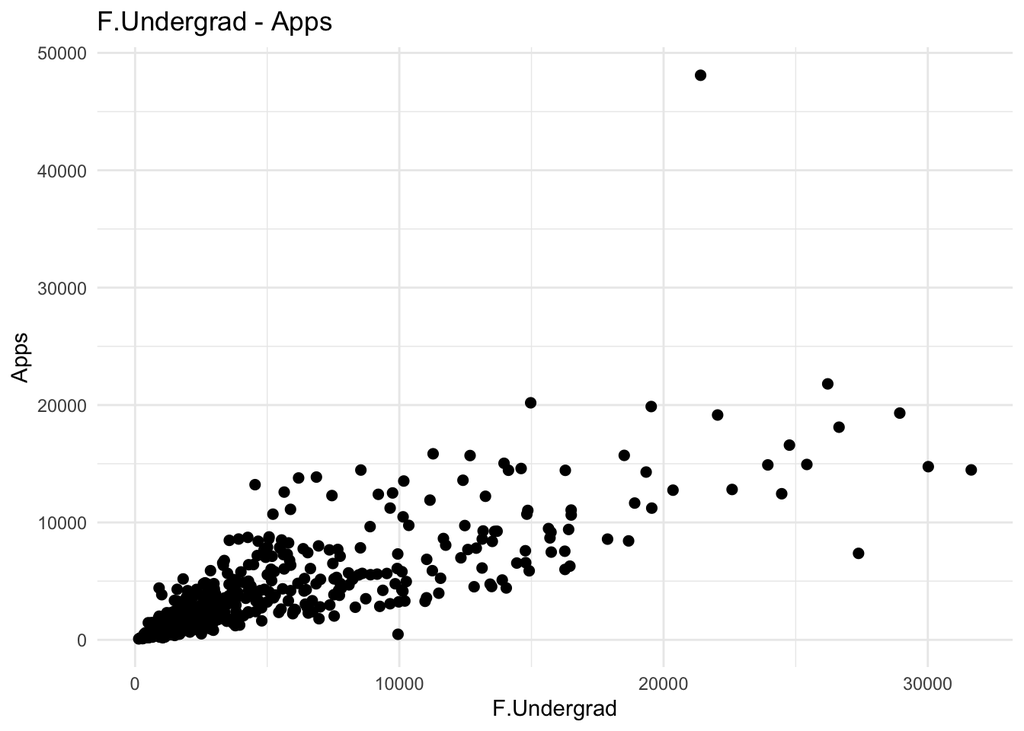

```r
ggplot(College, aes(x = F.Undergrad, y = Apps)) +
  geom_point(size = 2) +
  labs(title = "F.Undergrad - Apps",
       x = "F.Undergrad", y = "Apps") +
  theme_minimal()
```

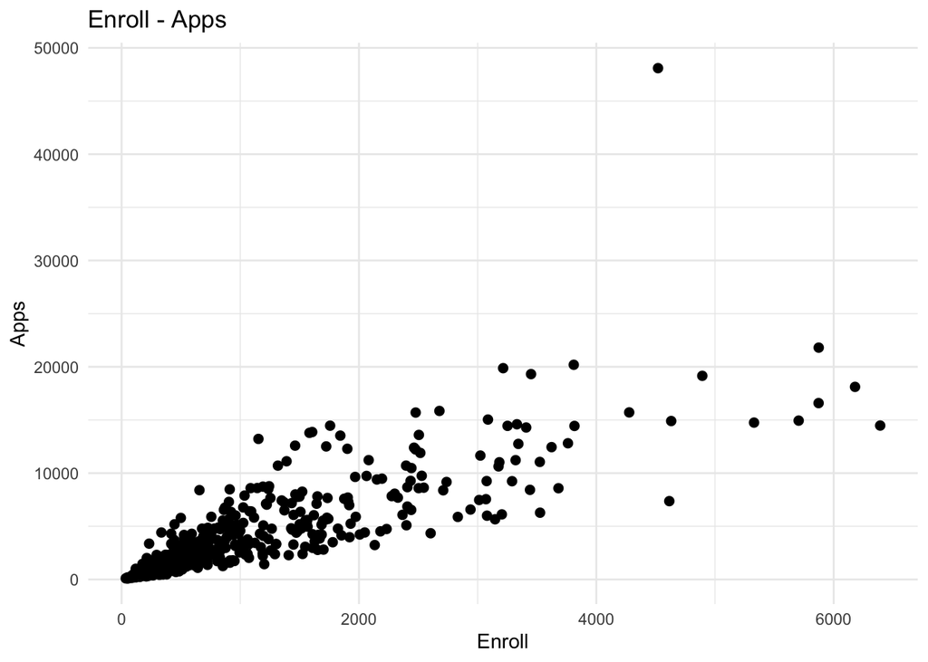

```r
ggplot(College, aes(x = Enroll, y = Apps)) +
  geom_point(size = 2) +
  labs(title = "Enroll - Apps",
       x = "Enroll", y = "Apps") +
  theme_minimal()
```

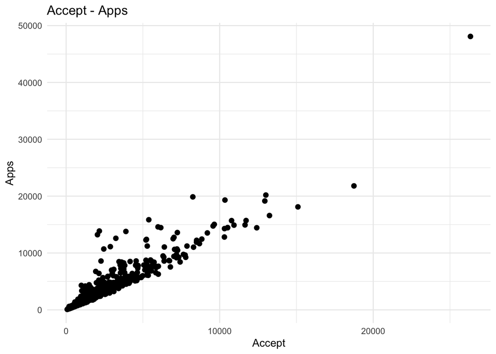

```r
ggplot(College, aes(x = Accept, y = Apps)) +
  geom_point(size = 2) +
  labs(title = "Accept - Apps",
       x = "Accept", y = "Apps") +
  theme_minimal()
```

F.Undergrad, Enroll, Accept은 Apps와 positive correlation을 갖는다는 것을 시각적으로 확인할 수 있다.

### (a) Split the data set into a training set and a test set.

```r
set.seed(123)

split = initial_split(College, prop = 0.75)

train_data = training(split)
test_data = testing(split)

print(nrow(train_data))
```

```
## [1] 582
```

```r
print(nrow(test_data))
```

```
## [1] 195
```

### (b) Fit a linear model using least squares on the training set, and report the test error obtained.

```r
lm_tmp = lm(Apps ~ ., data = train_data)
summary(lm_tmp)
```

```
##
## Call:
## lm(formula = Apps ~ ., data = train_data)
##
## Residuals:
##     Min      1Q  Median      3Q     Max
## -3262.8  -434.0   -60.1   325.9  6553.2
##
## Coefficients:
##               Estimate Std. Error t value Pr(>|t|)
## (Intercept) -357.51636  455.03029  -0.786 0.432374
## PrivateYes  -634.41730  157.19688  -4.036 6.19e-05 ***
## Accept         1.25726    0.05664  22.198  < 2e-16 ***
## Enroll        -0.27787    0.20084  -1.384 0.167038
## Top10perc     46.23226    6.02057   7.679 7.12e-14 ***
## Top25perc    -14.28980    4.92667  -2.900 0.003871 **
## F.Undergrad    0.09259    0.03576   2.589 0.009872 **
## P.Undergrad    0.01370    0.03441   0.398 0.690564
## Outstate      -0.04842    0.02072  -2.337 0.019785 *
## Room.Board     0.17243    0.05135   3.358 0.000839 ***
## Books          0.17278    0.27453   0.629 0.529365
## Personal      -0.02580    0.07087  -0.364 0.715956
## PhD           -7.50832    5.18958  -1.447 0.148507
## Terminal      -4.40205    5.53844  -0.795 0.427054
## S.F.Ratio      0.30257   14.07008   0.022 0.982851
## perc.alumni   -7.16154    4.53523  -1.579 0.114876
## Expend         0.07847    0.01319   5.950 4.72e-09 ***
## Grad.Rate     10.13370    3.24004   3.128 0.001853 **
## ---
## Signif. codes:  0 '***' 0.001 '**' 0.01 '*' 0.05 '.' 0.1 ' ' 1
##
## Residual standard error: 989.5 on 564 degrees of freedom
## Multiple R-squared:  0.9193, Adjusted R-squared:  0.9169
## F-statistic: 378.1 on 17 and 564 DF,  p-value: < 2.2e-16
```

```r
model = lm(Apps ~ Private + Accept + Enroll + Top10perc + Outstate + Expend, data = College)
summary(model)
```

```
##
## Call:
## lm(formula = Apps ~ Private + Accept + Enroll + Top10perc + Outstate +
##     Expend, data = College)
##
## Residuals:
##     Min      1Q  Median      3Q     Max
## -5123.6  -450.9    13.7   320.8  7677.5
##
## Coefficients:
##               Estimate Std. Error t value Pr(>|t|)
## (Intercept) -350.55532  128.61524  -2.726  0.00656 **
## PrivateYes  -369.59985  127.60185  -2.897  0.00388 **
## Accept         1.60271    0.04012  39.945  < 2e-16 ***
## Enroll        -0.62458    0.11240  -5.557 3.79e-08 ***
## Top10perc     33.40665    3.09022  10.810  < 2e-16 ***
## Outstate      -0.07867    0.01627  -4.834 1.61e-06 ***
## Expend         0.08005    0.01125   7.118 2.51e-12 ***
## ---
## Signif. codes:  0 '***' 0.001 '**' 0.01 '*' 0.05 '.' 0.1 ' ' 1
##
## Residual standard error: 1067 on 770 degrees of freedom
## Multiple R-squared:  0.9246, Adjusted R-squared:  0.924
## F-statistic:  1573 on 6 and 770 DF,  p-value: < 2.2e-16
```

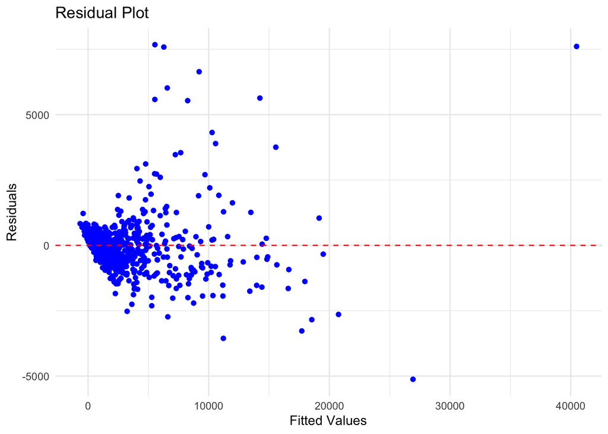

```r
#train set에 대한 residual
residuals = resid(model)
fitted_values = fitted(model)

residual_data = data.frame(Fitted = fitted_values, Residuals = residuals)

ggplot(residual_data, aes(x = Fitted, y = Residuals)) +
  geom_point(color = "blue") +
  geom_hline(yintercept = 0, linetype = "dashed", color = "red") +
  labs(title = "Residual Plot",
       x = "Fitted Values",
       y = "Residuals") +
  theme_minimal()
```

Private, Accept, Enroll, Top10perc, Outstate, Expend -> 6개의 predictors를 Apps prediction에 사용했다.  
adjusted R-squred가 0.924로 해당 모델은 상당히 높은 설명력을 갖는다고 할 수 있다. PrivateYes의 계수를 보면 -369.60의 값을 갖는다.사립 학교인 경우, 공립 학교보다 약 370개의 지원서를 덜 받는다고 해석이 가능하다.

```r
y_pred = predict(model, newdata = test_data)
test_data = test_data %>% mutate(y_pred)

residuals = test_data$Apps - y_pred
RSS = sum(residuals^2)
MSE_linear_model = mean((test_data$Apps - y_pred)^2)

print(RSS)
```

```
## [1] 246638190
```

```r
print(MSE_linear_model)
```

```
## [1] 1264811
```

### (c) Fit a ridge regression model on the training set, with $\lambda$ chosen by cross-validation. Report the test error obtained, along with the number of non-zero coefficient estimates.

```r
x_train = model.matrix(Apps ~ Private + Accept + Enroll + Top10perc + Outstate + Expend, data = train_data)[, -1]
y_train = train_data$Apps

x_test = model.matrix(Apps ~ Private + Accept + Enroll + Top10perc + Outstate + Expend, data = test_data)[, -1]
y_test = test_data$Apps

ridge_cv = cv.glmnet(x_train, y_train, alpha = 0)
optimal_lambda = ridge_cv$lambda.min
optimal_lambda
```

```
## [1] 318.83
```

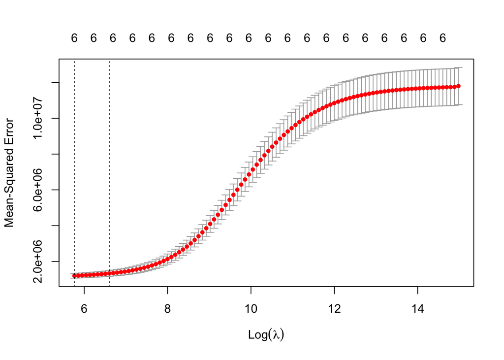

```r
plot(ridge_cv)
```

```r
ridge_model = glmnet(x_train, y_train, alpha = 0, lambda = optimal_lambda)
y_pred = predict(ridge_model, s = optimal_lambda, newx = x_test)
```

```r
MSE = mean((y_test - y_pred)^2)
print(MSE)
```

```
## [1] 2918240
```

```r
print(MSE_linear_model)
```

```
## [1] 1264811
```

```r
print(MSE - MSE_linear_model)
```

```
## [1] 1653428
```

ridge MSE : 2918240  
linear model MSE : 1264811  
ridge MSE - linear model MSE = 1653428

```r
RSS <- sum((y_test - y_pred)^2)
TSS <- sum((y_test - mean(y_test))^2)
r_squared_ridge = 1 - RSS/TSS
r_squared_ridge
```

```
## [1] 0.8801237
```

r_squared_linear_model : 0.9246  
r_squared_ridge_model : 0.8801

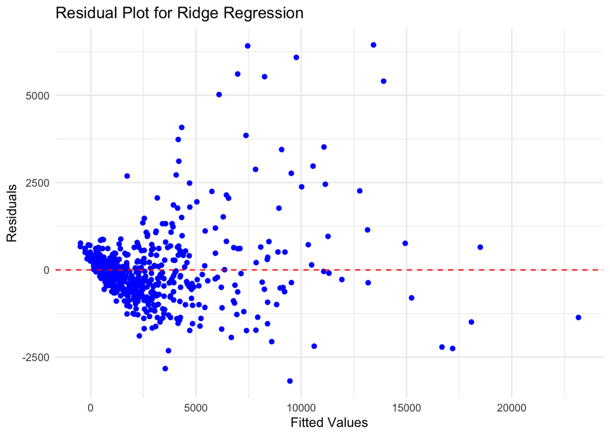

```r
fitted_values_ridge = predict(ridge_model, s = optimal_lambda, newx = x_train)
residuals_ridge = y_train - fitted_values_ridge

# 데이터프레임 생성
residual_data_ridge = data.frame(Fitted = fitted_values_ridge, residuals = residuals_ridge)

# 잔차 플롯 그리기
ggplot(residual_data_ridge, aes(x = s1, y = s1.1)) +
  geom_point(color = "blue") +
  geom_hline(yintercept = 0, linetype = "dashed", color = "red") +
  labs(title = "Residual Plot for Ridge Regression",
       x = "Fitted Values",
       y = "Residuals") +
  theme_minimal()
```